# Homework

18099

2018

# A-2018-09-14

# example 1

```r
a<-matrix(1:9,3,3)
b<-matrix(2:4,3,1)
a%*%b
```

```
##      [,1]
## [1,]   42
## [2,]   51
## [3,]   60
```

# example 2

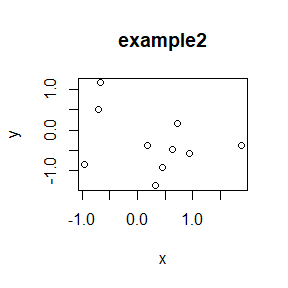

```r
x=rnorm(10)
y=rnorm(10)
plot(x,y,main="example2")
```

#example 3

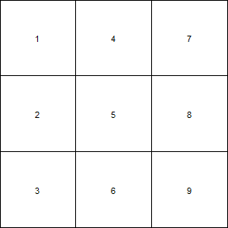

```r
layout(matrix(1:9,3,3))
layout.show(9)
```

# A-2018-9-21

## Question

A discrete random variable X has probability mass function x

| x | 0 | 1 | 2 | 3 | 4 |
| --- | --- | --- | --- | --- | --- |
| p(x) | 0.1 | 0.2 | 0.2 | 0.2 | 0.3 |

Use the inverse transform method to generate a random sample of size 1000 from the distribution of X. Construct a relative frequency table and compare the empirical with the theoretical probabilities. Repeat using the R sample function.

## Answer

```r
library(ggplot2)
set.seed(123)#guarantee that the program can be repeated with the same result
x <- 0:4#define r.v. x
p <- c(0.1,0.2,0.2,0.2,0.3)#the relative probability of x
cp <- cumsum(p)#cumulative sum of probability
m <- 1000#size of samples
r <- numeric(m)#construct a zero vector with length of 1000
r <- x[findInterval(runif(m),cp)+1]
# Generate 1000 sample from a uniform distribution and find where does every sample fall in the interval of cp.Every interval corresponds a value of random variable x.
table_r <- table(r)
print(table_r)
```

```
## r
##   0   1   2   3   4
##  99 197 211 198 295
```

```r
#theoretical probability
t_p <- p*1000
names(t_p) <- x
print(t_p)#show the theoretical 1000 samples
```

```
##   0   1   2   3   4
## 100 200 200 200 300
```

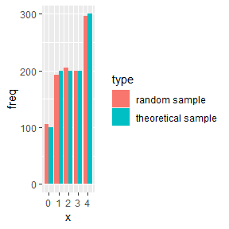

```r
a <- data.frame(x,freq = c(105,193,205,200,297,100,200,200,200,300),type = rep(c('random sample','theoretical sample'),each = 5))
ggplot(a,aes(x = x ,y =freq ,fill = type))+geom_col(position = 'dodge')
```

Firstly, I use the inverse transform method to generate 1000 samples from distribution x,which is shown as the table. More details can be seen in the comment of the code.

As the figure shows, the difference is very tiny with a relatively large sample. So we can regard the inverse transform method as a appoximation to the theoretical distribution.

## Question

Write a function to generate a random sample of size n from the Beta(*a*, *b*) distribution by the acceptance-rejection method. Generate a random sample of size 1000 from the Beta(3,2) distribution. Graph the histogram of the sample with the theoretical Beta(3,2) density superimposed.

## Answer

As known to all, Beta function is defined as $B(a,b)=\int_0^1x^{a-1}(1-x)^{b-1}dx$, and the pdf of Beta distribution is $f(x,a,b)=\frac{1}{B(a,b)}x^{a-1}(1-x)^{b-1}$. Then I use the acceptance-rejection method to define a function which aims to generate a vector of samples of length n from beta distribution,with parameters a and b. At last, I make a histogram to confirm that this is a valid function.

```r
set.seed(300)
beta_arm <- function(n,a,b){
  beta_pdf <- function(x){
    (1/beta(a,b))*(x)^(a-1)*(1-x)^(b-1)#define the pdf of beta distribution
  }
  j <- 0#the time of iteration
  k <- 0#the available sample
  y <- numeric(n)#a zero vector of length n
  while (k < n){
    u <- runif(1)
    j <- j + 1
    x <- runif(1) #random variate from g
    if ((a-1)*x^(a-2) * (b-1)*(1-x)^(b-2) > u) {
      #accept x
      k <- k + 1
      y[k] <- x
    }
  }
  return(y)
}
sample_beta <- beta_arm(1000,3,2)#record the sample
head(sample_beta,20)
```

```
##  [1] 0.7633293 0.7337780 0.4989520 0.9010106 0.5835977 0.9856363 0.6632547
##  [8] 0.5019594 0.4937491 0.8951302 0.7135011 0.4574379 0.7590429 0.7726191
## [15] 0.8711923 0.8697149 0.3472456 0.7474410 0.7988835 0.9937237
```

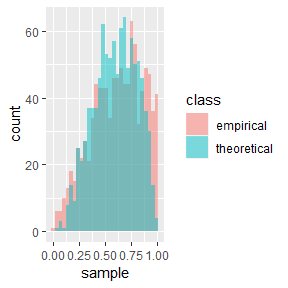

```r
sample_beta_theo <- rbeta(1000,3,2)#generate the sample by using the function "rbeta"
data_beta <- data.frame(sample = c(sample_beta,sample_beta_theo),class = rep(c('empirical','theoretical'),each = 1000))#construst a data frame in order to generate a figure
ggplot(data_beta,aes(x = sample,fill = class))+geom_histogram(position="identity", alpha=0.5)
```

## Question

Simulate a continuous Exponential-Gamma mixture. Suppose that the rate parameter $\Lambda$ has $Gamma(r,\beta)$ distribution and $Y$ has $Exp(\lambda)$ distribution. That is, $(Y|\Lambda=\lambda)~f_Y(y|\lambda)=\lambda e-\lambda y$. Generate 1000 random observations from this mixture with $r=4$ and $\beta=2$ .

## Answer

Firstly, I define two parameters of gamma distribution.Then I use this particular gamma distribution to generate 1000 samples, which are the parameter lambda of exponential distribution. Next, I use the function “rexp” generating 1000 samples x from the exponential distribution. Lastly, I plot the histogram of x.

```r
set.seed(100)
n <- 1000
r <- 4
beta <- 2#define the parameters
lambda <- rgamma(n, r, beta)#generate the random sample from the gamma distribution with r=4, beta=2
x <- rexp(n, lambda)
head(x,30)#list the first 30 samples
```

```
##  [1] 1.10721499 0.04071207 0.23685938 0.15667222 0.36077733 4.13047095
##  [7] 0.16765465 0.35399977 0.45644836 0.18735422 0.17796040 0.03156079
## [13] 0.81424975 0.17220415 0.08106887 1.10505797 1.73400032 0.31593086
## [19] 0.87663298 0.19869703 0.20644768 1.21781571 0.22988464 0.18111098
## [25] 0.54893716 0.42111507 1.04479466 0.24134687 1.35092841 0.23016093
```

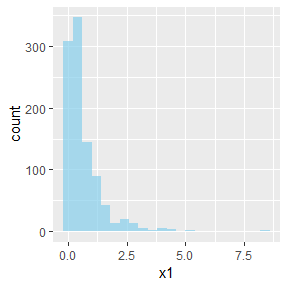

```r
x_data <- data.frame(x1 = x)
ggplot(x_data,aes(x = x1))+geom_histogram(fill = 'skyblue',alpha =0.7,binwidth = 0.4)
```

# A-2018-09-28

# Answer of 5.4

Since the Beta(3,3) cdf is
$$F(x)=\int_{0}^{x}\dfrac{1}{beta(3,3)}t^2(1-t)^2dt=E[g(X)]$$
,where $g(x)=xt^2(1-t)^2/beta(3,3),X\sim U(0,1)$, So we have the function

```r
MC_Beta<-function(x)
{
  m<-1e5
  y<-runif(m,min=0,max=x)
  F_beta_hat<-mean(x*y^2*(1-y)^2/beta(3,3))
  return(signif(F_beta_hat,4))
}
```

If we choose $x=0.1,\cdots,0.9$,use the function above and compare it with values return from pbeta

```r
pbeta_1<-function(x)
{
  return(pbeta(x,3,3))
}
x=seq(0.1,0.9,0.1)
cdf=sapply(x,MC_Beta)
est_cdf=sapply(x,pbeta_1)
A=signif(rbind(x,cdf,est_cdf),3)
print(A)
```

```
##            [,1]   [,2]  [,3]  [,4]  [,5]  [,6]  [,7]  [,8]  [,9]
## x       0.10000 0.2000 0.300 0.400 0.500 0.600 0.700 0.800 0.900
## cdf     0.00853 0.0581 0.163 0.318 0.501 0.683 0.837 0.941 0.993
## est_cdf 0.00856 0.0579 0.163 0.317 0.500 0.683 0.837 0.942 0.991
```

# Answer of 5.9

If X have a Rayleigh distribution, then it gives the cdf of X
$$F(x)=1-e^{-x^2/(2\sigma^2)}, \ x\geq0$$
$$x=\sqrt{-2\sigma^2log(1-y)},\ 0 \leq y \leq 1$$
Thus we can gennerate samples from
$$X=\dfrac{\sqrt{-2\sigma^2log(1-U)}+\sqrt{-2\sigma^2log(U)}}{2},U\sim U(0,1)$$
We have the function

```r
sample_Ray<-function(m,sigma)  ##X/2+X'/2
{
  x=runif(m)
  g=sqrt(-2*sigma^2*log(1-x))/2+sqrt(-2*sigma^2*log(x))/2
  return(g)
}
Asample_Ray<-function(m,sigma)  ##X1/2+X2/2
{
  x1=runif(m)
  x2=rinif(m)
  g=sqrt(-2*sigma^2*log(1-x1))/2+sqrt(-2*sigma^2*log(1-x2))/2
  return(g)
}
```

# Answer of 5.13

We choose these two importance functions:
$$f_1(x)=e^{1/2}xe^{-x^2/2},1<x<\infty$$
$$f_2(x)=\dfrac{1}{\sqrt{2\pi}}e^{-x^2/2},-\infty < x < \infty$$
for $f_1(x)$
$$F_1(x)=1-e^{1/2-x^2/2}$$
So we can generate samples of $f_1(x)$ from
$$x=\sqrt{1-2log(1-u)} \,\ u \sim U(0,1)$$
For $f_2(x)$, since it is normal density function, we can generate samples by function rnorm directly.

```r
m=1e5
g<-function(x)
{
  x^2*exp(-x^2/2)/sqrt(2*pi)*(x>1)
}

u=runif(m)   ##f_1
x=sqrt(1-2*log(1-u))
fg=g(x)/(exp(1/2)*x*exp(-x^2/2))
MC_1=sd(fg)

x=rnorm(m)  ##f_2
fg=sqrt(2*pi)*g(x)/exp(-x^2/2)
MC_2=sd(fg)
se=c(MC_1,MC_2)
print(se)  ##output the sd of f_1 and f_2
```

```
## [1] 0.1226015 1.1418041
```

From the result,we can see that $f_1(x)$ produce smaller variance.

## Answer of 5.14

As shown in Answer of 5.13, we choose the important function as
$$f_1(x)=e^{1/2}xe^{-x^2/2},1<x<\infty$$
Thus,after generate m samples we have

```r
m=1e5
g<-function(x)
{
  x^2*exp(-x^2/2)/sqrt(2*pi)*(x>1)
}

u=runif(m)   ##f_1
x=sqrt(1-2*log(1-u))
fg=g(x)/(exp(1/2)*x*exp(-x^2/2))
theta_hat=mean(fg)
print(theta_hat)
```

```
## [1] 0.4009382
```

It shows the result.

# A-2018-10-12

# Answer of 6.9

To estimate the mean,median and deciles , we generate m replicates $T^{(j)}$ by n samples from the distrubution of X.

```r
n=20
m=1000
Gi_sam1<-numeric(m)
Gi_sam2<-numeric(m)
Gi_sam3<-numeric(m)
for(i in 1:m)
{
  x<-sort(rlnorm(n,0,1))
  y<-sort(runif(n,0,1))
  z<-sort(rbinom(n,1,0.5))
  J=2*seq(1:n)-n-1
  Gi_sam1[i]=(J%*%x)/(n^2*mean(x))
  Gi_sam2[i]=(J%*%y)/(n^2*mean(y))
  Gi_sam3[i]=(J%*%z)/(n^2*mean(z))
}
log_norm<-c(mean(Gi_sam1),median(Gi_sam1),quantile(Gi_sam1,seq(0,1,0.1)))
unif_norm<-c(mean(Gi_sam2),median(Gi_sam1),quantile(Gi_sam2,seq(0,1,0.1)))
Bern_norm<-c(mean(Gi_sam2),median(Gi_sam1),quantile(Gi_sam3,seq(0,1,0.1)))
A=signif(rbind(log_norm,unif_norm,Bern_norm),3)
colnames(A)=c("mean","median",names(quantile(Gi_sam1,seq(0,1,0.1))))
print(A)
```

[output not shown]

Density histograms are shown below.

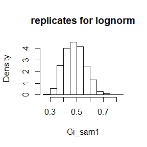

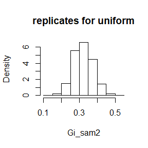

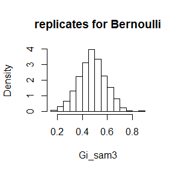

# Answer of 6.10

With m in a large number, we have the asymptotic distribution about G
$$\frac{\sqrt{m}(\hat G -\gamma)}{\sigma} \sim N(0,1)$$
a 95% confidence interval for $gamma$is given by
$$\left[\hat G- \frac{u_{0.975}\sigma}{\sqrt{m}} , \hat G +\frac{u_{0.975}\sigma}{\sqrt{m}}\right]$$
where u denote fractile of standardized normal distribution.

```r
n=30
m=100
alpha=0.025
Gi_sam1=numeric(m)
UCL_low<-numeric(1000)
UCL_upp<-numeric(1000)
Mean<-numeric(1000)
for(k in 1:1000)
{ for(i in 1:m) #generate m replitcates
{
  x<-sort(rlnorm(n,0,1))
  J=2*seq(1:n)-n-1
  Gi_sam1[i]=(J%*%x)/(n^2*mean(x))
}

  UCL_low[k]<-  mean(Gi_sam1)-qnorm(1-alpha)*sd(Gi_sam1)/sqrt(m)
  UCL_upp[k]<-  mean(Gi_sam1)+qnorm(1-alpha)*sd(Gi_sam1)/sqrt(m)
  Mean[k]<-mean(Gi_sam1)
}
fin_mean<-mean(Mean)
k=sum(UCL_low<fin_mean & UCL_upp>fin_mean)
mean1<-k/1000
```

From the result, we kanow that its coverage rate is

```
## [1] 0.952
```

it is close to 95%.

# Answer of 6.B

```r
library(MASS)
m=1000
n=200
ratio<-matrix(0,3,10)
for(j in 1:10)
{
  mean<-c(0,1)
  sigma=matrix(c(1,j/20,j/20,1),2,2)
  p_pearson<-numeric(m)
  p_Spearman<-numeric(m)
  p_Kendall<-numeric(m)
  for(i in 1:m)
  {
    sample=mvrnorm(n,mean,sigma)
    x=sample[,1]
    y=sample[,2]
    test1<-cor.test(x,y,method="pearson")
    test2<-cor.test(x,y,method="kendall")
    test3<-cor.test(x,y,method="spearman")
    p_pearson[i]<-test1$p.value
    p_Spearman[i]<-test2$p.value
    p_Kendall[i]<-test3$p.value
  }

  ratio[,j]=c(mean(p_pearson<0.05),mean(p_Spearman<0.05),mean(p_Kendall<0.05))
}
rownames(ratio)<-c("pearson","speqrman","Kendall")
print(ratio)
```

```
##           [,1]  [,2]  [,3]  [,4]  [,5]  [,6]  [,7] [,8] [,9] [,10]
## pearson  0.093 0.316 0.577 0.814 0.956 0.993 0.998    1    1     1
## speqrman 0.104 0.282 0.530 0.774 0.926 0.991 0.997    1    1     1
## Kendall  0.100 0.284 0.531 0.773 0.929 0.992 0.996    1    1     1
```

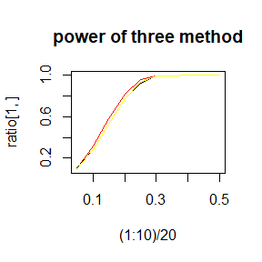

```r
plot((1:10)/20,ratio[1,],type="l",col="RED",main="power of three method")
lines((1:10)/20,ratio[2,],type="l",col="BLACK")
lines((1:10)/20,ratio[3,],type="l",col="YELLOW")
```

```r
library(MASS)
m=1000
n=200
mean<-c(0,1)
sigma=matrix(c(1,0,0,1),2,2)
p_pearson<-numeric(m)
p_Spearman<-numeric(m)
p_Kendall<-numeric(m)
for(i in 1:m)
{
  sample=mvrnorm(n,mean,sigma)
  x=sample[,1]
  y=sample[,2]
  test1<-cor.test(x,y,method="pearson")
  test2<-cor.test(x,y,method="kendall")
  test3<-cor.test(x,y,method="spearman")
  p_pearson[i]<-test1$p.value
  p_Spearman[i]<-test2$p.value
  p_Kendall[i]<-test3$p.value
}

ratio=c(mean(p_pearson<0.05),mean(p_Spearman<0.05),mean(p_Kendall<0.05))
names(ratio)<-c("peason","Speqrman","Kendall")
print(ratio)
```

```
##   peason Speqrman  Kendall
##    0.045    0.046    0.046
```

# A-2018-11-02

# Question 7.1

Compute a jackknife estimate of the bias and the standard error of the correlation statistic in Example 7.2

# Answer of 7.1

Delete $j_{th}$ samples to obtain n replitates, which are used to estimating.The code is shown below.

```r
library(bootstrap)
n=length(law$GPA)
theta.hat<-cor(law$LSAT,law$GPA)
theta.jack<-numeric(n)
for(i in 1:n)      #leave one out
{
  theta.jack[i]<-cor(law$LSAT[-i],law$GPA[-i])
}
bias.jack<-(mean(theta.jack)-theta.hat)*(n-1)
se.jack<-sqrt((n-1)/n*sum((theta.jack-mean(theta.jack))^2))
round(c(original=theta.hat,bias=bias.jack,se=se.jack),3)
```

```
## original     bias       se
##    0.776   -0.006    0.143
```

# Question 7.5

Refer to Exercise 7.4. Compute 95% bootstrap confidence intervals for the mean time between failures $1/\lambda$ by the standard normal, basic, percentile, and BCa methods. Compare the intervals and explain why they may differ.

# Answer of 7.5

Its known that wth n observations the MLE of $1/\lambda$ is $\overline X$.Here is the code for confidence intervals.

```r
library(boot)
hour<-aircondit
B=200     #number of repicates
data<-hour
theta.boot<-function(data,i) #compute statisic
{
  mean(data[i,])
}
boot.obj<-boot(data,statistic = theta.boot,R=2000)
```

the mean and sd of $1/\lambda$ is shown below.

```r
print(boot.obj)
```

```
##
## ORDINARY NONPARAMETRIC BOOTSTRAP
##
##
## Call:
## boot(data = data, statistic = theta.boot, R = 2000)
##
##
## Bootstrap Statistics :
##     original   bias    std. error
## t1* 108.0833 1.129125    37.28508
```

And confidence intervals for differents method is shown below.

```r
print(boot.ci(boot.obj,type=c("basic","norm","perc","bca")))
```

```
## BOOTSTRAP CONFIDENCE INTERVAL CALCULATIONS
## Based on 2000 bootstrap replicates
##
## CALL :
## boot.ci(boot.out = boot.obj, type = c("basic", "norm", "perc",
##     "bca"))
##
## Intervals :
## Level      Normal              Basic
## 95%   ( 33.9, 180.0 )   ( 25.1, 167.8 )
##
## Level     Percentile            BCa
## 95%   ( 48.4, 191.1 )   ( 58.1, 229.1 )
## Calculations and Intervals on Original Scale
## Some BCa intervals may be unstable
```

# Question 7.8

Refer to Exercise 7.7. Obtain the jackknife estimates of bias and standard error of $\hat \theta$.

# Answer of 7.8

We leave one row put form the score matrix to obtain the jackknife eatimates.

```r
n=nrow(scor)
theta.an<-function(x) #compute theta
{
  eigen(x)$values[1]/sum(eigen(x)$values)
}
theta.hat1<-theta.an(var(scor))
theta.jack1<-numeric(n)
for(i in 1:n)
{
  theta.jack1[i]<-theta.an(var(scor[-i,]))
}
bias.jack1<-(mean(theta.jack1)-theta.hat1)*(n-1)
se.jack1<-sqrt((n-1)/n*sum((theta.jack1-mean(theta.jack1))^2))
round(c(original=theta.hat1,bias=bias.jack1,se=se.jack1),5)
```

```
## original     bias       se
##  0.61912  0.00107  0.04955
```

It can be learn form above that the jackknife of bias and standard error of $\hat \theta$ is 0.00107 and 0.04955.

# Queation 7.11

In Example 7.18, leave-one-out (n-fold) cross validation was used to select the best fitting model. Use leave-two-out cross validation to compare the models.

# Answer of 7.11

Follow the code in Example 7.18,we have

```r
library(DAAG)
attach(ironslag)
n=length(magnetic)
e1<-e2<-e3<-e4<-numeric()
#leave-two-out

for(k in 1:(n-1))
{ l=k+1
y=magnetic[c(-k,-l)]
x=chemical[c(-k,-l)]

J1<-lm(y ~ x)
yhat_a1<-J1$coef[1] + J1$coef[2]*chemical[k]

yhat_b1<-J1$coef[1] + J1$coef[2]*chemical[l]
e1<-c(e1,magnetic[k]-yhat_a1)
e1<-c(e1,magnetic[l]-yhat_b1)

J2<-lm(y ~ x+I(x^2))
yhat_a2<-J2$coef[1] + J2$coef[2]*chemical[k]+J2$coef[3]*chemical[k]^2
yhat_b2<-J2$coef[1] + J2$coef[2]*chemical[l]+J2$coef[3]*chemical[l]^2
e2<-c(e2,magnetic[k]-yhat_a2)
e2<-c(e2,magnetic[l]-yhat_b2)


J3<-lm(log(y) ~ x)
logyhat_a3<-J3$coef[1] + J3$coef[2]*chemical[k]
logyhat_b3<-J3$coef[1] + J3$coef[2]*chemical[l]
e3<-c(e3,magnetic[k]-exp(logyhat_a3))
e3<-c(e3,magnetic[l]-exp(logyhat_b3))

J4<-lm(log(y) ~ log(x))
logyhat_a4<-J4$coef[1] + J4$coef[2]*log(chemical[k])
logyhat_b4<-J4$coef[1] + J4$coef[2]*log(chemical[l])
e4<-c(e4,magnetic[k]-exp(logyhat_a4))
e4<-c(e4,magnetic[l]-exp(logyhat_b4))
}
c(mean(e1^2),mean(e2^2),mean(e3^2),mean(e4^2))
```

```
## [1] 20.05231 17.96998 18.58856 20.74569
```

Obviously, the second model have the lower errors than the other models.

# A-2018-11-16

## Exercise 8.1

Implement the two-sample Cramer-von Mises test for equal distributions as a permutation test. Apply the test to the data in Examples 8.1 and 8.2.

## Answer

X and Y are independent random samples form F and G.
$$F = G \ vs \ F \neq G$$
Obtained from Google, the function “CvM.test” in the packsge “RVAideMemoire” is uesed to compute Cramer-vom Mises statistic. Thus We write a function to compute the p-value with data x and y provided.

```r
CVM<-function(x,y){
  N=999#permutation numbers
  n<-length(x);
  m<-length(y);
  f<-ecdf(x);
  g<-ecdf(y);
  z<-c(x,y);
  t<-numeric(N);
  t0<-m*n/(m+n)^2*(sum((f(x)-g(x))^2)+sum((f(y)-g(y))^2));
  for(i in 1:N){
    k<-sample(length(z),size=n,replace = FALSE);
    x1<-z[k];
    y1<-z[-k];
    f1<-ecdf(x1);
    g1<-ecdf(y1);
    t[i]<-m*n/(m+n)^2*(sum((f1(x)-g1(x))^2)+sum((f1(y)-g1(y))^2))
  }
  p <- mean(c(t0,t) >= t0)
  return(p)
}
```

Applying thos function to the data in Example 8.1.

```r
attach(chickwts)
x <- sort(as.vector(weight[feed == "soybean"]))
y <- sort(as.vector(weight[feed == "linseed"]))
fin <- CVM(x,y)
fin
```

```
## [1] 0.411
```

```r
detach(chickwts)
```

Clearly, the result shows that the null hypothesis is not rejected, that is $F = G$.

## Question

Design experiments for evaluating the performance of the NN, energy, and ball methods in various situations

## Answer

We write all these function and change the data.

1:Unequal variances and equal expectations

```r
set.seed(1)
##install.packages("RANN")
##install.packages("energy")
##install.packages("Ball")
library(RANN)
library(boot)
library(energy)
library(Ball)

m <- 50
k<-3
p<-2
n1 <- n2 <- 50
R<-999
n <- n1+n2
N = c(n1,n2)

Tn <- function(z, ix, sizes,k)  {
  n1 <- sizes[1]
  n2 <- sizes[2]
  n <- n1 + n2
  if(is.vector(z)) z <- data.frame(z,0)
  z <- z[ix, ]
  NN <- nn2(data=z, k=k+1)
  block1 <- NN$nn.idx[1:n1,-1]
  block2 <- NN$nn.idx[(n1+1):n,-1]
  i1 <- sum(block1 < n1 + .5); i2 <- sum(block2 > n1+.5)
  (i1 + i2) / (k * n)
}

eqdist.nn <- function(z,sizes,k){
  boot.obj <- boot(data=z,statistic=Tn,R=R,sim = "permutation", sizes = sizes,k=k)
  ts <- c(boot.obj$t0,boot.obj$t)
  p.value <- mean(ts>=ts[1])
  list(statistic=ts[1],p.value=p.value)
}

p.values <- matrix(NA,m,3)
for(i in 1:m){
  x <- matrix(rnorm(n1*p,mean = 1,sd = 0.6),ncol=p);
  y <- matrix(rnorm(n2*p,mean = 1,sd = 0.85),ncol=p);
  z <- rbind(x,y)
  p.values[i,1] <- eqdist.nn(z,N,k)$p.value
  p.values[i,2] <- eqdist.etest(z,sizes=N,R=R)$p.value
  p.values[i,3] <- bd.test(x=x,y=y,R=999,seed = i*12)$p.value
}

alpha <- 0.1;
pow1 <- colMeans(p.values<alpha)
print(pow1)
```

```
## [1] 0.46 0.56 0.82
```

2:Unequal variances and unequal expectations

```r
set.seed(1)
p.values <- matrix(NA,m,3)
for(i in 1:m){
  x <- matrix(rnorm(n1*p,mean = 0.4,sd = 0.6),ncol=p);
  y <- matrix(rnorm(n2*p,mean = 0.5,sd = 0.85),ncol=p);
  z <- rbind(x,y)
  p.values[i,1] <- eqdist.nn(z,N,k)$p.value
  p.values[i,2] <- eqdist.etest(z,sizes=N,R=R)$p.value
  p.values[i,3] <- bd.test(x=x,y=y,R=999,seed = i*12)$p.value
}
alpha <- 0.1;
pow2<- colMeans(p.values<alpha)
print(pow2)
```

```
## [1] 0.42 0.62 0.86
```

3:Non-normal distributions: t distribution with 1 df (heavy-tailed distribution), bimodeldistribution (mixture of two normal distributions)

```r
set.seed(1)
p.values <- matrix(NA,m,3)
for(i in 1:m){
  # t distribution with 1 df (heavy-tailed distribution)
  x <- matrix(rt(n1*p,df = 1),ncol=p);
  #bimodel distribution (mixture of two normal distributions)
  y <- cbind(rnorm(n2,mean = 0.4),rnorm(n2,mean = 0.5));
  z <- rbind(x,y)
  p.values[i,1] <- eqdist.nn(z,N,k)$p.value
  p.values[i,2] <- eqdist.etest(z,sizes=N,R=R)$p.value
  p.values[i,3] <- bd.test(x=x,y=y,R=999,seed = i*12)$p.value
}
alpha <- 0.1
pow3 <- colMeans(p.values<alpha)
print(pow3)
```

```
## [1] 0.94 1.00 1.00
```

```r
set.seed(1)
p.values <- matrix(NA,m,3)
for(i in 1:m){
  x <- c(rnorm(n1,mean = 1,sd = 1))
  y <- c(rnorm(n2,mean = 2,sd = 2))
  z <- c(x,y)
  p.values[i,1] <- eqdist.nn(z,N,k)$p.value
  p.values[i,2] <- eqdist.etest(z,sizes=N,R=R)$p.value
  p.values[i,3] <- bd.test(x=x,y=y,R=999,seed = i*12)$p.value
}
alpha <- 0.1
pow4 <- colMeans(p.values<alpha)
print(pow4)
```

```
## [1] 0.94 1.00 1.00
```

## Exercise 9.3

Use the Metropolis-Hastings sampler to generate random variables from a standard Cauchy distribution. Discard the first 1000 of the chain, and compare the deciles of the generated observations with the deciles of the standard Cauchy distribution (see qcauchy or qt with df=1). Recall that a Cauchy($\theta$, $\eta$) distribution has density function
$$f(x)=\dfrac{1}{\theta \pi (1+[(x-\eta)/\theta]^2)}, -\infty < x < \infty ,\theta > \ 0$$

The standard Cauchy has the Cauchy($\theta$ = 1, $\eta$ = 0) density.

## Answer

Consider $N(X_t,\sigma^2)$ as the proposal diatribution.

```r
f <- function(x,theta,eta)
{
  stopifnot(theta > 0)
  return(1/(theta*pi*(1 + ((x-eta)/theta)^2)))
}
m=5000
theta=1
eta=0
sigma <- 1
x <- numeric(m)
x[1] <- rnorm(1, 0, sigma)
k=0
u <- runif(m)

for(i in 2:m)
{
  xt <- x[i-1]
  y<- rnorm(1, mean = xt, sd = sigma)
  num <-f(y,theta,eta) *dnorm(xt, mean = y, sd = sigma)
  den <-f(xt, theta, eta) * dnorm(y, mean = xt, sd = sigma)
  if(u[i] <= num/den) x[i] <- y
  else{
    x[i]<-xt
    k=k+1
  }
}
print(k/m)
```

```
## [1] 0.2472
```

The rejection rate is 0.2472

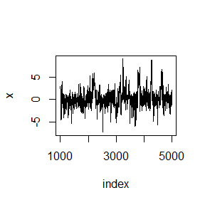

```r
b0=1001
index=b0:m
y=x[index]
plot(y~index , type="l", main="",ylab="x")
```

Compare deciles with the theoretical Cauchy(0,1)

```r
p=seq(0.1,0.9,0.1)
round( rbind(quantile(y,p), qcauchy(p)),3)
```

```
##         10%    20%    30%    40%   50%   60%   70%   80%   90%
## [1,] -1.824 -1.127 -0.619 -0.268 0.017 0.317 0.727 1.338 2.655
## [2,] -3.078 -1.376 -0.727 -0.325 0.000 0.325 0.727 1.376 3.078
```

The histgram of the chain is shown below.

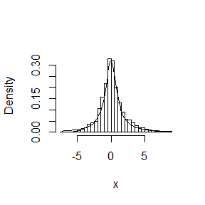

```r
hist(y,prob=T,main='',xlab='x',breaks=50)
xarg=seq(min(y),max(y),0.1)
lines(xarg,f(xarg,theta,eta))
```

## Answer

```r
set.seed(906)

f <- function( theta,x )  {
  if (theta<0 || theta>1 ) return (0)
  (2+theta)^x[1] * (1-theta)^(x[2]+x[3]) * theta^x[4]
}
xdata = c( 125, 18, 20, 34 )
m = 10000
th = numeric(m)
th[1] = runif(1)
k = 0
u = runif(m)

for (t in 2:m) {
  xt = th[t-1]
  alph = xt/(1-xt)
  y <- rbeta(1, shape1=alph, shape2=1 )
  numer = f( y,xdata ) * dbeta( xt, y/(1-y), 1)
  denom = f( xt,xdata ) * dbeta( y, alph, 1)
  if ( u[t] <= numer/denom )
    th[t] = y else {
      th[t] = th[t-1]
      k = k + 1
    }
}
```

Thus,the estimation of $\theta$ is

```r
theta.hat = mean( th[2001:m] )
print(theta.hat)
```

```
## [1] 0.623192
```

# A-2018-11-23

## Exercise11.4

Find the intersection points A(k) in $(0,\sqrt(k)$ of the curse
$$S_{k-1}(a)=1-t_{k-1}(\sqrt(a^2(k-1)/(k-a^2)))$$
and
$$S_{k}(a)=1-t_{k}(\sqrt(a^2k/(K+1-a^2)))$$
for k=4:25,100,500,1000. ##Answer Since
$$S_{k-1}(a)=1-t_{k-1}(\sqrt(a^2(k-1)/(k-a^2)))$$
$$S_{k}(a)=1-t_{k}(\sqrt(a^2k/(K+1-a^2)))$$
where $t_{k}()$ means distribution function of student t. So it equals to find points such that
$$f(a)=t_{k-1}(\sqrt(a^2(k-1)/(k-a^2)))-t_{k}(\sqrt(a^2k/(k+1-a^2)))=0$$

```r
ft<-function(a,df){
s1=pt(q=sqrt(a^2*(df-1)/(df-a^2)),df=(df-1),lower =   FALSE)
s2=pt(q=sqrt(a^2*df/(df+1-a^2)),df=df,lower= FALSE)
return(s1-s2)
 }
 kt=c(4:25,100,500,1000)
out=numeric(length(kt))
for(i in 1:length(kt))
{
out[i]=uniroot(ft,lower = 0.001,upper =2,df=kt[i])$root
}
rbind(kt,out)
```

```
##         [,1]     [,2]     [,3]    [,4]     [,5]     [,6]     [,7]
## kt  4.000000 5.000000 6.000000 7.00000 8.000000 9.000000 10.00000
## out 1.492103 1.533556 1.562745 1.58443 1.601185 1.614521  1.62539
##          [,8]      [,9]     [,10]     [,11]     [,12]     [,13]     [,14]
## kt  11.000000 12.000000 13.000000 14.000000 15.000000 16.000000 17.000000
## out  1.634419  1.642038  1.648554  1.654191  1.659114  1.663452  1.667304
##         [,15]    [,16]     [,17]     [,18]     [,19]    [,20]     [,21]
## kt  18.000000 19.00000 20.000000 21.000000 22.000000 23.00000 24.000000
## out  1.670746  1.67384  1.676637  1.679178  1.681496  1.68362  1.685572
##         [,22]      [,23]      [,24]       [,25]
## kt  25.000000 100.000000 500.000000 1000.000000
## out  1.687374   1.720608   1.729755    1.730907
```

# A-2018-12-7

## Answer

```r
attach(mtcars)
xt<-list(disp,I(1/disp),disp+wt,I(1/disp)+wt)
##for loop
lm1<-list()
for(i in seq_along(xt)){
  lm1[[i]]<-lm(mpg~xt[[i]])
}
lm1
```

```
## [[1]]
##
## Call:
## lm(formula = mpg ~ xt[[i]])
##
## Coefficients:
## (Intercept)      xt[[i]]
##    29.59985     -0.04122
##
##
## [[2]]
##
## Call:
## lm(formula = mpg ~ xt[[i]])
##
## Coefficients:
## (Intercept)      xt[[i]]
##       10.75      1557.67
##
##
## [[3]]
##
## Call:
## lm(formula = mpg ~ xt[[i]])
##
## Coefficients:
## (Intercept)      xt[[i]]
##    29.67540     -0.04097
##
##
## [[4]]
##
## Call:
## lm(formula = mpg ~ xt[[i]])
##
## Coefficients:
## (Intercept)      xt[[i]]
##      37.357       -5.357
```

```r
##lapply
lm2<-lapply(xt,function(x) lm(mpg~x))
lm2
```

```
## [[1]]
##
## Call:
## lm(formula = mpg ~ x)
##
## Coefficients:
## (Intercept)            x
##    29.59985     -0.04122
##
##
## [[2]]
##
## Call:
## lm(formula = mpg ~ x)
##
## Coefficients:
## (Intercept)            x
##       10.75      1557.67
##
##
## [[3]]
##
## Call:
## lm(formula = mpg ~ x)
##
## Coefficients:
## (Intercept)            x
##    29.67540     -0.04097
##
##
## [[4]]
##
## Call:
## lm(formula = mpg ~ x)
##
## Coefficients:
## (Intercept)            x
##      37.357       -5.357
```

```r
detach(mtcars)
```

## Exercise 4(Page 204)

Fit the model mpg ~ disp to each of the bootstrap replicates of mtcars in the list below by using a for loop and lapply(). Can you do it without an anonymous function?

# Answer

```r
bootstraps <- lapply(1:10, function(i) {
  rows <- sample(1:nrow(mtcars), rep = TRUE)
  mtcars[rows, ]
})
##lappply
lm3<-lapply(bootstraps, function(x) lm(x$mpg~x$disp))
lm3
```

```
## [[1]]
##
## Call:
## lm(formula = x$mpg ~ x$disp)
##
## Coefficients:
## (Intercept)       x$disp
##    31.15083     -0.04704
##
##
## [[2]]
##
## Call:
## lm(formula = x$mpg ~ x$disp)
##
## Coefficients:
## (Intercept)       x$disp
##    29.95878     -0.04295
##
##
## [[3]]
##
## Call:
## lm(formula = x$mpg ~ x$disp)
##
## Coefficients:
## (Intercept)       x$disp
##    28.27271     -0.03534
##
##
## [[4]]
##
## Call:
## lm(formula = x$mpg ~ x$disp)
##
## Coefficients:
## (Intercept)       x$disp
##    27.93659     -0.03325
##
##
```

[output cut: 43 more lines]

```
## lm(formula = x$mpg ~ x$disp)
##
## Coefficients:
## (Intercept)       x$disp
##    33.39359     -0.05473
##
##
## [[10]]
##
## Call:
## lm(formula = x$mpg ~ x$disp)
##
## Coefficients:
## (Intercept)       x$disp
##    32.27530     -0.05172
```

```r
##for loop
lm4<-list()
for(i in seq_along(bootstraps)){
  lm4[[i]]<-lm(bootstraps[[i]]$mpg~bootstraps[[i]]$disp)
}
lm4
```

```
## [[1]]
##
## Call:
## lm(formula = bootstraps[[i]]$mpg ~ bootstraps[[i]]$disp)
##
## Coefficients:
##          (Intercept)  bootstraps[[i]]$disp
##             31.15083              -0.04704
##
##
## [[2]]
##
## Call:
## lm(formula = bootstraps[[i]]$mpg ~ bootstraps[[i]]$disp)
##
## Coefficients:
##          (Intercept)  bootstraps[[i]]$disp
##             29.95878              -0.04295
##
##
## [[3]]
##
## Call:
## lm(formula = bootstraps[[i]]$mpg ~ bootstraps[[i]]$disp)
##
## Coefficients:
##          (Intercept)  bootstraps[[i]]$disp
##             28.27271              -0.03534
##
##
## [[4]]
##
## Call:
## lm(formula = bootstraps[[i]]$mpg ~ bootstraps[[i]]$disp)
##
## Coefficients:
##          (Intercept)  bootstraps[[i]]$disp
##             27.93659              -0.03325
##
##
```

[output cut: 43 more lines]

```
## lm(formula = bootstraps[[i]]$mpg ~ bootstraps[[i]]$disp)
##
## Coefficients:
##          (Intercept)  bootstraps[[i]]$disp
##             33.39359              -0.05473
##
##
## [[10]]
##
## Call:
## lm(formula = bootstraps[[i]]$mpg ~ bootstraps[[i]]$disp)
##
## Coefficients:
##          (Intercept)  bootstraps[[i]]$disp
##             32.27530              -0.05172
```

## Answer

```r
##Exercise 3
sapply(lm1,function(mod) summary(mod)$r.squared)
```

```
## [1] 0.7183433 0.8596865 0.7198637 0.7516013
```

```r
sapply(lm2,function(mod) summary(mod)$r.squared)
```

```
## [1] 0.7183433 0.8596865 0.7198637 0.7516013
```

```r
##Exercise 4
sapply(lm3,function(mod) summary(mod)$r.squared)
```

```
##  [1] 0.7924735 0.7328890 0.6075031 0.5824178 0.6426212 0.6664233 0.7982539
##  [8] 0.7147637 0.7800549 0.7628389
```

```r
sapply(lm4,function(mod) summary(mod)$r.squared)
```

```
##  [1] 0.7924735 0.7328890 0.6075031 0.5824178 0.6426212 0.6664233 0.7982539
##  [8] 0.7147637 0.7800549 0.7628389
```

## Exercise 3(Page 213)

The following code simulates the performance of a t-test for non-normal data. Use sapply() and an anonymous function to extract the p-value from every trial.

## Answer

```r
trials <- replicate(
  100,
  t.test(rpois(10, 10), rpois(7, 10)),
  simplify = FALSE
)

sapply(trials,function(x) x$p.value)
```

```
##   [1] 0.50217978 0.99283370 0.88975051 0.92165701 0.74952151 0.45499184
##   [7] 0.12573434 0.10657775 0.85365459 0.61423023 0.15102243 0.10787406
##  [13] 0.49028609 0.81126886 0.68524130 0.73124816 0.72638715 0.95874523
##  [19] 0.41968789 0.16576999 0.73288254 0.68178521 0.52050681 0.43261122
##  [25] 0.21497436 0.40894960 0.06976335 0.91384775 0.88260498 0.27556417
##  [31] 0.34844401 0.26199753 0.91257133 0.71422375 0.58292936 0.95908978
##  [37] 0.47783385 0.73223142 0.40720945 0.75102659 0.35569249 0.97183504
##  [43] 0.92018955 0.75684862 0.13704752 0.54144597 0.15625654 0.90562110
##  [49] 0.52669469 0.50617167 0.03165466 0.44104989 0.38545826 0.21854548
##  [55] 0.71333795 0.08275610 0.41503615 0.13374756 0.94086853 0.24574422
##  [61] 0.07483718 0.02292553 0.55171298 0.06296646 0.92977539 0.62214097
##  [67] 0.11264672 0.42033297 0.51283000 0.23285038 0.65499791 0.79306785
##  [73] 0.18248603 0.09044500 0.97432775 0.56454066 0.09491707 0.66376992
##  [79] 0.05689756 0.68777961 0.66394755 0.51823794 0.31696172 0.25560146
##  [85] 0.51816686 0.08316252 0.53744823 0.54984655 0.49912369 0.73834566
##  [91] 0.19003507 0.73880407 0.83312892 0.37140914 0.09207995 0.67229287
##  [97] 0.77703029 0.15108552 0.74506604 0.49186519
```

# A-2018-12-14

## Question 4

Make a faster version of chisq.test() that only computes the chi-square test statistic when the input is two numeric vectors with no missing values. You can try simplifying chisq.test() or by coding from the mathematical definition

## Answer

```r
options(warn=-1)
set.seed(123)
my_chi<-function(x,y)
{
  if (length(x) != length(y))
    stop("'x' and 'y' must have the same length")
  OK <- complete.cases(x, y)
  x <- factor(x[OK])
  y <- factor(y[OK])
  if ((nlevels(x) < 2L) || (nlevels(y) < 2L))
    stop("'x' and 'y' must have at least 2 levels")
  x <- table(x, y)
  p = rep(1/length(x), length(x))
  p <- p/sum(p)
  n<-sum(x)
  E <- n * p
  V <- n * p * (1 - p)
  STATISTIC <- sum((x - E)^2/E)
  STATISTIC
}

x<-runif(10)
y<-runif(10)

my_chi(x,y)
```

```
## [1] 90
```

```r
chisq.test(x,y)$statistic
```

```
## X-squared
##        90
```

```r
library(microbenchmark)
microbenchmark(
  my_chi(x,y),
  chisq.test(x,y)$statistic
)
```

```
## Unit: microseconds
##                        expr     min        lq      mean    median
##                my_chi(x, y) 374.216  412.9015  646.3834  518.2975
##  chisq.test(x, y)$statistic 945.803 1172.9775 1639.1565 1490.1530
##         uq      max neval
##   765.0115 3595.709   100
##  1950.8175 3512.024   100
```

It can be seen that “my_chi” is much faster than “chisq.test” as twice.

## Question 5

Can you make a faster version of table() for the case of an input of two integer vectors with no missing values? Can you use it to speed up your chi-square test?

## Answer

```r
options(warn=-1)
my_table<-function(x,y){
  args<-list(x,y)
  bin <- 0L
  lens <- NULL
  dims <- integer()
  pd <- 1L
  dn <- NULL
  for (a in args) {

    fact.a <- is.factor(a)
    if (!fact.a) {
      a0 <- a
      a <- factor(a)
    }
    ll <- levels(a)
    a <- as.integer(a)
    nl <- length(ll)
    dims <- c(dims, nl)
    if (prod(dims) > .Machine$integer.max)
      stop("attempt to make a table with >= 2^31 elements")
    dn <- c(dn, list(ll))
    bin <- bin + pd * (a - 1L)
    pd <- pd * nl
  }
  bin <- bin[!is.na(bin)]
  if (length(bin))
    bin <- bin + 1L
  y <- array(tabulate(bin, pd), dims, dimnames = dn)
  class(y) <- "table"
  y
}


library(microbenchmark)
x<-1:4
y<-2:5
my_table(x,y)
```

```
##   2 3 4 5
## 1 1 0 0 0
## 2 0 1 0 0
## 3 0 0 1 0
## 4 0 0 0 1
```

```r
table(x,y)
```

```
##    y
## x   2 3 4 5
##   1 1 0 0 0
##   2 0 1 0 0
##   3 0 0 1 0
##   4 0 0 0 1
```

```r
microbenchmark(
  my_table(x,y),
  table(x,y)
)
```

```
## Unit: microseconds
##            expr     min      lq     mean  median       uq      max neval
##  my_table(x, y) 191.451 195.990 266.0058 201.714 244.5440 1713.972   100
##     table(x, y) 235.267 241.978 294.3246 249.478 283.4255  726.721   100
```

It can be seen the function “my table”" is a little faster than “table”. Apply this to “my_chi” to speed up my chi-square test.

```r
options(warn=-1)
myy_chi<-function(x,y)
{
  if (length(x) != length(y))
  stop("'x' and 'y' must have the same length")
  OK <- complete.cases(x, y)
  x <- factor(x[OK])
  y <- factor(y[OK])
  if ((nlevels(x) < 2L) || (nlevels(y) < 2L))
  stop("'x' and 'y' must have at least 2 levels")
  x <- my_table(x,y)
  p = rep(1/length(x), length(x))
  p <- p/sum(p)
  n<-sum(x)
  E <- n * p
  V <- n * p * (1 - p)
  STATISTIC <- sum((x - E)^2/E)
  STATISTIC
}

x<-runif(10)
y<-runif(10)

microbenchmark(
myy_chi(x,y),
my_chi(x,y),
chisq.test(x,y)$statistic
)
```

```
## Unit: microseconds
##                        expr     min       lq      mean  median        uq
##               myy_chi(x, y) 307.110 334.7425  603.7276 359.019  420.4010
##                my_chi(x, y) 351.717 375.9925  460.4559 398.493  450.0075
##  chisq.test(x, y)$statistic 882.645 928.8295 1080.7896 970.672 1102.5155
##        max neval
##  20916.213   100
##   1027.515   100
##   2460.036   100
```

Surprsingly, using “my_table” makes chisqusre test faster, although quite a little bit.